# Chapter 10: The Priorities and Prioritization Tables

# Chapter Introduction

In Chapter 9, we introduced the `scheduleSun()` and `scheduleFixed()` functions to populate a Google Calendar for smartphone-based monitoring. In this chapter, we introduce new functions that optimize the sampling schedules based on when species are most likely to be captured by smartphone monitoring (i.e. adaptive sampling). This process involves the **temporals**, **priorities**, **prioritization** and **schedule** tables of an **AMMonitor** database.

The premise of adaptive sampling with **AMMonitor** is to schedule sampling events such that false negatives are minimized. For example, if a target monitoring species is present on site but does not vocalize during a scheduled audio recording session, researchers may incorrectly conclude that the species is absent from the site (‘false negative’). The risk of false negatives increases when devices do not monitor on a continuous basis and must be scheduled to operate at specific times of day, due to data transmission constraints, for example. However, determining the optimal sampling schedule is challenging, especially when monitoring multiple species whose activity patterns vary across temporal and environmental conditions. If data transmission constraints limit the total amount of monitoring that can occur, we want to leverage the sampling resources we have by scheduling monitoring events that maximize the probability of capture (*sensu* [1]) for all target species.

**AMMonitor’s** temporally adaptive sampling algorithm is designed to maximize detection probabilities for a suite of focal species amid sampling constraints. The algorithm combines user-supplied species “activity” models (stored in the **ammls directory**) with site-specific weather forecasts (stored in the **temporals** table) to set an optimized sampling schedule for the following day. For example, an activity model for the Verdin (a songbird) provides the probability that a Verdin will be acoustically available (i.e., singing) within each hour at each site for the next 24 hours, given forecasted temporal conditions at a site and knowledge of Verdin behavior. A “stopping rule” for monitoring Verdin at each site can be invoked based on the cumulative likelihood that the species has already been acoustically captured. Thus, if it is likely that Verdin vocalized in previous monitoring efforts, we can drop Verdin from the prioritization scheme and focus our monitoring resources on species that have yet to be captured. In simulation work, we have found that over the course of a study season, the probability of acoustically capturing a focal species at least once via automated acoustic monitoring is higher (and acoustic capture occurs earlier in the season) when using the temporally adaptive optimized schedule as compared to a fixed schedule, potentially reducing the risk of false negatives and providing more confidence in detection probability estimates [2].

For this chapter, we will use the `dbCreateSample()` function to create a database called “Chap10.sqlite”, which will be stored in a folder (directory) called **database** within the **AMMonitor** main directory (which should be your working directory in R). Recall that `dbCreateSample()` generates all tables of an **AMMonitor** database, and then pre-populates sample data into tables specified by the user.

Below, we use `dbCreateSample()` to pre-populate several necessary tables. We will auto-populate additional tables using **AMMonitor** functions later on in the chapter:

```r
# Create a sample database for this chapter
dbCreateSample(db.name = "Chap10.sqlite",
               file.path = paste0(getwd(),"/database"),
               tables =  c('locations', 'deployment', 'equipment',
                           'accounts', 'species', 'priorities',
                           'temporals', 'people'))
```

```
## An AMMonitor database has been created with the name Chap10.sqlite which consists of the following tables:
```

```
## accounts, annotations, assessments, classifications, deployment, equipment, library, listItems, lists, locations, logs, objectives, people, photos, priorities, prioritization, recordings, schedule, scores, scriptArgs, scripts, soundscape, spatials, species, sqlite_sequence, templates, temporals
```

```
##
## Sample data have been generated for the following tables:
## accounts, people, species, equipment, locations, deployment, priorities, temporals
```

Now, we connect to the database. First, we initialize a character object, **db.path**, that holds the database’s full file path. Then, we create a database connection object, **conx**, using RSQLite’s `dbConnect()` function, where we identify the SQLite driver in the ‘drv’ argument, and our **db.path** object in the ‘dbname’ argument:

```r
# Establish the database file path as db.path
db.path <- paste0(getwd(), '/database/Chap10.sqlite')

# Connect to the database
conx <- RSQLite::dbConnect(drv = dbDriver('SQLite'), dbname = db.path)
```

After that, we send a SQL statement that will enforce foreign key constraints.

```r
# Turn the SQLite foreign constraints on
RSQLite::dbSendQuery(conn = conx, statement = "PRAGMA foreign_keys = ON;")
```

```
## <SQLiteResult>
##   SQL  PRAGMA foreign_keys = ON;
##   ROWS Fetched: 0 [complete]
##        Changed: 0
```

Finally, to keep the demonstrations in this chapter concise, we will assume that only three of our 50 sample monitoring locations are actively being monitored. That is, we will pretend that the equipment deployed at 47 locations has been retrieved.

We will deactivate deployments at monitoring locations ‘location@4’ through ‘location@50’ by sending an UPDATE query to `dbExecute()`, wherein we assign an arbitrary date to the *dateRetrieved* column of the deployment table to indicate that the devices at these locations have been retrieved and the locations are not actively monitored:

```r
# Set an equipment retrieval date for all locations but 3
RSQLite::dbExecute(
  conn = conx,
  statement =  "UPDATE deployment
                SET dateRetrieved = '2016-01-20'
                WHERE locationID
                NOT IN ('location@1', 'location@2', 'location@3')")
```

```
## [1] 47
```

This action returns a ‘47’ to indicate that 47 records have applied the action of setting *dateRetrieved* equal to ‘2016-01-20’.

# The Priorities Table

The **priorities** table allows us to store monitoring priorities for focal species at each active monitoring location. Depending on our research program, we might prioritize the capture of certain species more highly than that of other species, and/or we might be particularly interested in capturing activity at certain sites more than others.

We begin by viewing the **priorities** table’s metadata with the function `dbTables()`:

```r
# Look at information about the priorities table
dbTables(db.path = db.path, table = "priorities")
```

```
## $priorities
##   cid       name         type notnull dflt_value pk comment
## 1   0 locationID VARCHAR(255)       1         NA  1
## 2   1  speciesID VARCHAR(255)       1         NA  2
## 3   2     weight         REAL       0         NA  0
## 4   3       pMax         REAL       0         NA  0
```

This table contains only four fields. The *locationID* and *speciesID* constitute primary keys, and reference *locationID* and *speciesID* from the **locations** and **species** tables, respectively. The *weight* value indicates the proportion of monitoring weight assigned to a particular species at a particular site, and depends on the monitoring program’s goals.

The *pMax* column stores the “probability of capture” value above which monitoring is no longer required for a target species at a given location. *pMax* values are chosen by the user, and indicate how certain users want to be that a target species has been captured before dropping that species from the schedule optimization scheme. Thus, *pMax* functions as a stopping rule. For example, a *pMax* value of 0.95 for a target species at a location indicates that monitoring will continue for that species at that location until we are 95% certain the species has been captured at least once on an audio recording or photo, given it is present. *pMax* may be greater than 1 for monitoring programs that focus on abundance of captures (e.g., number of vocalizations by a target species, or number of times a species was camera-trapped) rather than probability of a single capture throughout the monitoring period.

To see how the **priorities** table works, we use `dbGetQuery()` to view all records in the sample table.

```r
# Retrieve the sample data stored in the priorites table
RSQLite::dbGetQuery(conn = conx, statement = 'SELECT * FROM priorities')
```

```
##    locationID speciesID weight pMax
## 1  location@1      btgn    0.2 0.95
## 2  location@1      copo    0.3 0.95
## 3  location@1      leni    0.3 0.95
## 4  location@1      verd    0.2 0.95
## 5  location@2      btgn    0.2 0.95
## 6  location@2      copo    0.3 0.95
## 7  location@2      leni    0.3 0.95
## 8  location@2      verd    0.2 0.95
## 9  location@3      btgn    0.2 0.95
## 10 location@3      copo    0.3 0.95
## 11 location@3      leni    0.3 0.95
## 12 location@3      verd    0.2 0.95
```

This example contains four target species at three locations. Focusing on location@1 only, “btgn” and “verd” have weights of 0.2, while “copo” and “leni” have weights of 0.3. From a monitoring perspective, this means “copo” and “leni” are 1.5 times more important than the other species (0.3/0.2 = 1.5). **Importantly, for any given location, the sum of the weights must equal 1 in the priorities table.** For location@1, 0.2 + 0.3 + 0.3 + 0.2 = 1. The *pMax* value for each species and site is set to 0.95, indicating that we wish to monitor each species with smartphones until we have exceeded a probability of 0.95 that we have captured the species at least once during the duration of our monitoring program.

Here, we have chosen to set the same *weight* and *pMax* values for all four species at each of three active monitoring locations. However, a user could elect to assign different monitoring weights to different species based on the location in order to better customize the monitoring optimization scheme to their needs.

**Note that this sample monitoring program is not necessarily limited to these four species. Rather, the four species listed drive the monitoring schedule that is pushed to each smartphone’s Google Calendar.**

The convenience function `prioritySet()` can be used to populate the **priorities** table. `prioritySet()` takes the database path in the ‘db.path’ argument. A vector of speciesIDs may be supplied in the ‘speciesID’ argument, or users may input a value of “all” to indicate that all species in the **species** table should be used. Lastly, the ‘p.max’ argument takes a real number. This function automatically populates the **priorities** table by first identifying all actively monitored locations. At each active location, it assigns equal priority weights to all species specified in the ‘speciesID’ argument. The same ‘p.max’ value is assigned for each species at each location. Lastly, the ‘db.insert’ argument allows users to test the function and view the outputs before committing new records to the **priorities** table. Below, we leave ‘db.insert’ as the default FALSE to demonstrate the function. The ‘db.insert’ argument in this function should be used with additional care: **If ‘db.insert’ is set to TRUE, any existing records in the priorities table will be overwritten.**

```r
# Demonstrate prioritySet(), but set db.insert to FALSE
prioritySet(db.path = db.path,
            speciesID = c('verd', 'btgn'),
            p.max = 0.99,
            db.insert = FALSE)
```

```
## Returning priorities, but no records have been overwritten in
##  the existing priorities table because db.insert = FALSE
```

```
##    locationID speciesID weight pMax
## 1: location@1      btgn    0.5 0.99
## 2: location@1      verd    0.5 0.99
## 3: location@2      btgn    0.5 0.99
## 4: location@2      verd    0.5 0.99
## 5: location@3      btgn    0.5 0.99
## 6: location@3      verd    0.5 0.99
```

In the above example, monitoring priorities for the three locations are driven by two species of equal monitoring importance. Monitoring for each species at each location will continue until a *pMax* of 0.99 is attained. Because *db.insert* is set to FALSE, this prioritization scheme will not be implemented; the priorities from the sample data will be used in the examples that follow.

# The Prioritization Table

While the **priorities** table is filled in manually by the monitoring team, the **prioritization** table is automatically filled by **AMMonitor** functions. The primary purpose of the **prioritization** table is to track, *through time*, the probability that a target species has been captured at a site. This table is populated by **AMMonitor** functions based on the probability that the species has been previously captured, given presence. Users do not interact with this table directly.

Below, we view the **prioritization** table’s metadata using `dbTables()`:

```r
# Look at information about the prioritization table
dbTables(db.path = db.path, table = "prioritization")
```

```
## $prioritization
##   cid       name         type notnull dflt_value pk comment
## 1   0 locationID VARCHAR(255)       1         NA  1
## 2   1  speciesID VARCHAR(255)       1         NA  2
## 3   2       date VARCHAR(255)       1         NA  3
## 4   3       pMax         REAL       0         NA  0
## 5   4   pCurrent         REAL       0         NA  0
## 6   5     weight         REAL       0         NA  0
## 7   6       init         REAL       0         NA  0
```

The *locationID*, *speciesID*, and *date* together constitute primary keys (a composite key), signifying that we are interested in tracking a target species’ probability of capture through time at each location. The *pMax* value is supplied by the **priorities** table.

On the first day of an optimized monitoring program, *init* is set to 1, the *weight* values are equal to those in the **priorities** table, and *pCurrent* is set to 0 for all species and location combinations. *pCurrent* tracks the current probability of having captured at least one signal from the target species throughout the monitoring period up to the current date. Monitoring may be initialized at any point in time. For instance, a user may reinitialize the monitoring program on the first day of the week, the first day of each month, or at any desired interval.

To initialize a monitoring program with an optimized recording schedule, we use the function `priorityInit()`, which contains two arguments. First, the ‘db.path’ argument receives the **db.path** object as an input. Second, we declare a date in YYYY-mm-dd format in the ‘init.date’ argument. Below, we input **Sys.Date()** to the ‘init.date’ argument to indicate that we want to initialize an optimized monitoring program today.

```r
# Run the priorityInit function:
priorityInit(db.path = db.path, init.date = Sys.Date())
```

```
## Finished initializing prioritization table.
```

We can use `dbGetQuery()` to confirm that our prioritization table has been initialized:

```r
# Check the freshly-initialized prioritization table using dbGetQuery:
RSQLite::dbGetQuery(conn = conx,
                    statement = 'SELECT * FROM prioritization')
```

```
##    locationID speciesID       date pMax pCurrent weight init
## 1  location@1      btgn 2019-07-12 0.95        0    0.2    1
## 2  location@1      copo 2019-07-12 0.95        0    0.3    1
## 3  location@1      leni 2019-07-12 0.95        0    0.3    1
## 4  location@1      verd 2019-07-12 0.95        0    0.2    1
## 5  location@2      btgn 2019-07-12 0.95        0    0.2    1
## 6  location@2      copo 2019-07-12 0.95        0    0.3    1
## 7  location@2      leni 2019-07-12 0.95        0    0.3    1
## 8  location@2      verd 2019-07-12 0.95        0    0.2    1
## 9  location@3      btgn 2019-07-12 0.95        0    0.2    1
## 10 location@3      copo 2019-07-12 0.95        0    0.3    1
## 11 location@3      leni 2019-07-12 0.95        0    0.3    1
## 12 location@3      verd 2019-07-12 0.95        0    0.2    1
```

Note that `priorityInit()` has initialized monitoring with a total of 12 rows, having repeated all four target species at each of our three active monitoring sites, and having assigned our specified *weight* and *pMax* values. Since monitoring has just been initialized, *pCurrent* values all begin at zero (because we have not detected any species yet), and the *init* column contains all ones. If you are following along and running the code in R, the *date* column should contain today’s date.

Our goal next is to create future monitoring events (e.g., recordings) that are pushed to each smartphone’s Google Calendar, given our monitoring priorities and any data transmission constraints limiting the number of events that can be collected. As monitoring progresses (where *init* $\ne$ 1), **AMMonitor** functions will change the *weight* and *pCurrent* values through time based on *previous* predicted probability of capture values that have accumulated since initialization. Weights generally recede for species with higher probabilities of capture, and increase for species whose probability of capture remains inadequate.

As a preview of the prioritization process, the figure below demonstrates how *pCurrent* and *weight* values change from the beginning (2016-03-01) to the end (2016-03-31) of a hypothetical monitoring scenario for location@1 only:

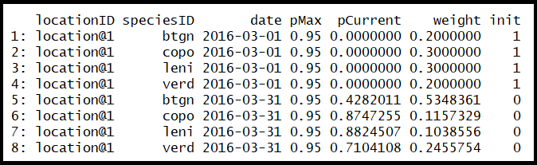

> *Figure 10.1. Hypothetical illustration of how pCurrent and weights change as monitoring progresses.*

In this example, on 2016-03-31, the probability that ‘btgn’ has been captured at this site is 0.42, while the probability that ‘leni’ has been captured at this site is 0.88. Because all *pCurrent* scores are less than *pMax*, all monitoring weights are greater than 0 (indicating that some monitoring effort will be applied for each of the four species at this location in the future). The *weight* column indicates that the future monitoring schedule (e.g., tomorrow) will target ‘btgn’ much more than the other species, because the *pCurrent* value for ‘btgn’ remains much lower.